# Housing Prices: A Supply and Demand Application of the *ecodata* Package

In this vignette, we will look at new housing construction costs, new housing sales prices, and the quantity of new house sales in the United States from 2021-2022, and use supply and demand reasoning to explain what happened in the U.S. housing market.

# 1 Prompts

1. Download data from FRED on median sales price for new houses in the United States for 2021-2022.
2. Download data from FRED on the number of sales for all new houses in the United States for 2021-2022 (hint: FRED describes this as “New Houses Sold by Sales Price in the United States, Total”).
3. Download data from FRED on construction costs for residential houses for 2021-2022 (hint: FRED describes this as “Producer Price Index by Commodity: Inputs to Residential Construction: New Housing Units Under Construction”).
4. Create time series plots for each of the three variables above.
5. Describe the behavior of each variable over 2021-2022.
6. Use the supply and demand model for new housing to explain what happened.

# 2 Download Data

The following are the variables for median sales price, number of sales, and construction cost index:

- Median sales price: https://fred.stlouisfed.org/series/MSPNHSUS
- Number of sales: https://fred.stlouisfed.org/series/NHSUSSPT
- Construction cost index: https://fred.stlouisfed.org/series/WPUIP2311001

Load the *tidyverse* and *ecodata* libraries and download the data:

```r
library(tidyverse)
library(ecodata)

# Identify the data
data_sources <- c(
  "https://fred.stlouisfed.org/series/MSPNHSUS",
  "https://fred.stlouisfed.org/series/NHSUSSPT",
  "https://fred.stlouisfed.org/series/WPUIP2311001"
)
variable_names <- c("Median Sales Price", "Number of Sales", "Construction Cost Index")

# Download the data
housingdata <- get_ecodata(data_sources, variable_names)

# Filter for only 2021-2022
housingdata <- housingdata |>
  filter(Date >= "2021-01-01", Date <= "2022-12-31")

# View the data
glimpse(housingdata)
```

```
#>
#> Rows: 24
#> Columns: 4
#> $ Date                      <date> 2021-01-01, 2021-02-01, 2021-03-01, 2021-04…
#> $ `Median Sales Price`      <dbl> 354800, 351400, 342700, 364400, 372700, 3611…
#> $ `Number of Sales`         <dbl> 77, 70, 83, 74, 65, 61, 62, 55, 58, 51, 54, …
#> $ `Construction Cost Index` <dbl> 240.600, 246.100, 253.600, 258.200, 268.100,…
```

```r
ecodata_description_table(housingdata)
```

| Variable | Code | Description | Frequency | Units | Seasonal Adjustment | Source | URL | Access Date |
| --- | --- | --- | --- | --- | --- | --- | --- | --- |
| Median Sales Price | MSPNHSUS | Median Sales Price for New Houses Sold in the United States | Monthly | $ | Not Seasonally Adjusted | FRED (R) Federal Reserve Bank of St. Louis | https://fred.stlouisfed.org/series/MSPNHSUS | October 31, 2024 |
| Number of Sales | NHSUSSPT | New Houses Sold by Sales Price in the United States, Total | Monthly | Thous. of Units | Not Seasonally Adjusted | FRED (R) Federal Reserve Bank of St. Louis | https://fred.stlouisfed.org/series/NHSUSSPT | October 31, 2024 |
| Construction Cost Index | WPUIP2311001 | Producer Price Index by Commodity: Inputs to Industries: Net Inputs to Residential Construction, Goods | Monthly | Index Jun 1986=100 | Not Seasonally Adjusted | FRED (R) Federal Reserve Bank of St. Louis | https://fred.stlouisfed.org/series/WPUIP2311001 | October 31, 2024 |

# 3 Plot the data

Since each variable is measured on a different scale (prices are in dollars, number of sales is in units, and the construction cost index is an index), we will plot each variable on a separate graph.

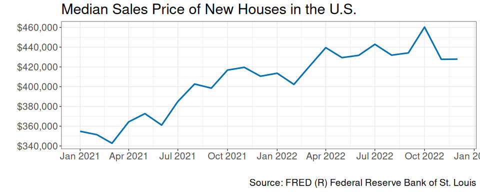

```r
# Housing Prices
ggplot_ecodata_ts(housingdata,
                  variables = "Median Sales Price",
                  title = "Median Sales Price of New Houses in the U.S.",
                  ylab = "")
```

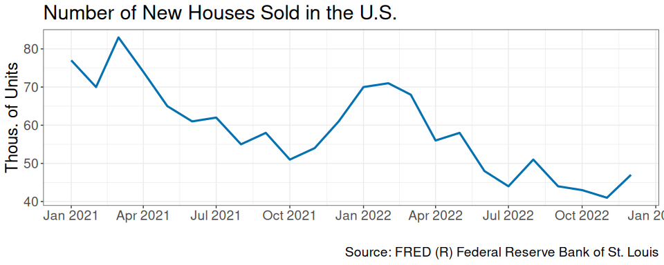

```r
# Quantity of Sales
ggplot_ecodata_ts(housingdata,
                  variables = "Number of Sales",
                  title = "Number of New Houses Sold in the U.S.")
```

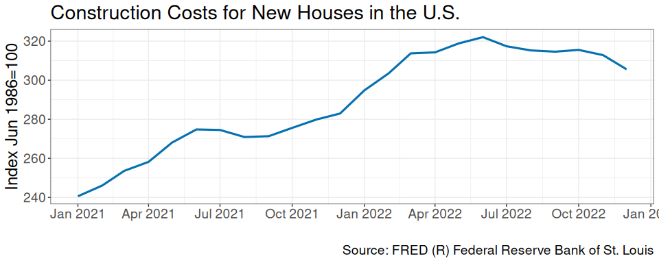

```r
# Construction Costs
ggplot_ecodata_ts(housingdata,
                  variables = "Construction Cost Index",
                  title = "Construction Costs for New Houses in the U.S.")
```

# 4 Observations

Construction costs increased from January 2021 until about July 2022. Over the two-year period 2021-2022, housing prices increased, but the quantity of new houses sold decreases.

# 5 Supply and Demand Analysis

An increase in construction costs increases the cost of producing new houses, which should lead to a decrease in supply. Below, we use a supply and demand model for new houses and shift the supply to the left.

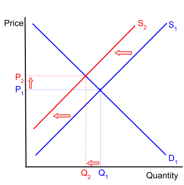

The leftward shift in supply leads to a higher equilibrium price and a lower equilibrium quantity. This is consistent with the U.S. housing market data from 2021-2022.